# Horse vs Human Dataset - Transfer Learning

## Pipelining the pre-trained model with our own:

First, let's get the last desired layer (last_output):

```python
last_desired_layer = pre_trained_model.get_layer('mixed7')
print('last layer output shape: ', last_desired_layer.output_shape)
last_output = last_desired_layer.output
print('last layer output: ', last_output)
```

Check that everything works as expected:

```
last layer output shape:  (None, 7, 7, 768)
last layer output:  KerasTensor(type_spec=TensorSpec(shape=(None, 7, 7, 768), dtype=tf.float32, name=None), name='mixed7/concat:0', description="created by layer 'mixed7'")
```

Now, we will create the final model by adding some additional layers on top of the pre-trained model.

```python
# Print the type of the pre-trained model
print(f"The pretrained model has type: {type(pre_trained_model)}")
```

```
The pretrained model has type: <class 'keras.engine.functional.Functional'>
```

To create the final model, you will use Keras' Model class by defining the appropriate inputs and outputs.

**Note that you can get the input from any existing model by using its `input` attribute and by using the Funcional API you can use the last layer directly as output when creating the final model.**

```python
from tensorflow.keras.optimizers import RMSprop

# Flatten the output layer to 1 dimension
x = layers.Flatten()(last_output)

# Add a fully connected layer with 1,024 hidden units and ReLU activation
x = layers.Dense(1024, activation='relu')(x)
# Add a dropout rate of 0.2
x = layers.Dropout(0.2)(x)
# Add a final sigmoid layer for classification
x = layers.Dense  (1, activation='sigmoid')(x)

# Create the complete model by using the Model class
model = Model(pre_trained_model.input, x)

# Compile the model
model.compile(optimizer = RMSprop(learning_rate=0.0001),
          loss = 'binary_crossentropy',
          metrics = ['accuracy'])
```

```python
# Inspect parameters
total_params = model.count_params()
num_trainable_params = sum([w.shape.num_elements() for w in model.trainable_weights])

print(f"There are {total_params:,} total parameters in this model.")
print(f"There are {num_trainable_params:,} trainable parameters in this model.")
```

```
There are 47,512,481 total parameters in this model.
There are 38,537,217 trainable parameters in this model.
```

### Let's now train the model

```python
callbacks = myCallback()
history = model.fit(train_generator,
                    validation_data = validation_generator,
                    epochs = 100,
                    verbose = 2,
                    callbacks=callbacks)
```

```
33/33 - 26s - loss: 0.1755 - accuracy: 0.9357 - val_loss: 0.0277 - val_accuracy: 0.9805 - 26s/epoch - 802ms/step
33/33 - 11s - loss: 0.0311 - accuracy: 0.9893 - val_loss: 0.0382 - val_accuracy: 0.9766 - 11s/epoch - 333ms/step
33/33 - 11s - loss: 0.0270 - accuracy: 0.9903 - val_loss: 0.0203 - val_accuracy: 0.9922 - 11s/epoch - 332ms/step
33/33 - 11s - loss: 0.0210 - accuracy: 0.9942 - val_loss: 0.0246 - val_accuracy: 0.9922 - 11s/epoch - 335ms/step
33/33 - 12s - loss: 0.0201 - accuracy: 0.9903 - val_loss: 0.0026 - val_accuracy: 1.0000 - 12s/epoch - 359ms/step
33/33 - 11s - loss: 0.0148 - accuracy: 0.9951 - val_loss: 0.0078 - val_accuracy: 0.9961 - 11s/epoch - 334ms/step
33/33 - 11s - loss: 0.0094 - accuracy: 0.9971 - val_loss: 0.0162 - val_accuracy: 0.9922 - 11s/epoch - 336ms/step
33/33 - 11s - loss: 0.0246 - accuracy: 0.9903 - val_loss: 0.0067 - val_accuracy: 0.9961 - 11s/epoch - 335ms/step

Reached 99.9% accuracy so cancelling training!
33/33 - 11s - loss: 0.0028 - accuracy: 0.9990 - val_loss: 0.0248 - val_accuracy: 0.9922 - 11s/epoch - 337ms/step
```

Now let's take a quick look at the training and validation accuracies for each epoch of training:

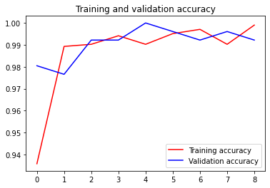

```python
# Plot the training and validation accuracies for each epoch

acc = history.history['accuracy']
val_acc = history.history['val_accuracy']
loss = history.history['loss']
val_loss = history.history['val_loss']

epochs = range(len(acc))

plt.plot(epochs, acc, 'r', label='Training accuracy')
plt.plot(epochs, val_acc, 'b', label='Validation accuracy')
plt.title('Training and validation accuracy')
plt.legend(loc=0)
plt.figure()

plt.show()
```